# Data 605 Homework Week-8

## —————————————————————————

### **Student Name :** Sachid Deshmukh

### **Date :** 03/19/2019

- > [GitHub Location for rmd file](https://github.com/mlforsachid/MSDSQ2Data605/blob/master/Week8/HW-8/SachidVijay.Deshmukh60.Rmd)
- > [RPubs location of published file](http://rpubs.com/sachid/Data605Week8HW)

## —————————————————————————

### Chapter 7 Exercise 11

**A company buys 100 lightbulbs, each of which has an exponential lifetime of 1000 hours. What is the expected time for the first of these bulbs to burn out?**

```r
sim.light = function(size=100, mean=1000, time=1000)
{
  min.light = c()
  for(i in 1:time)
  {
    exp = rexp(size,1/mean)
    min.light[i] = min(exp)
  }
  return (mean(min.light))
}

print(paste("Expected time for the first of these bulbs to burn out = ", sim.light()))
```

```
## [1] "Expected time for the first of these bulbs to burn out =  10.4321567067354"
```

### Chapter 7 Exercise 14

**Assume that X1 and X2 are independent random variables, each having an exponential density with parameter lambda. Show that Z=X1-X2 has density fZ(z)=(1/2)e(-lambda X Z).**

```r
sim.exp = function(size=1000, lambda=5)
{
  num = runif(size, min = -7, max = 10)
  pos.num = num[num>=0]
  neg.num = num[num < 0]
  pos.num.den = lambda * (exp(-lambda*pos.num))
  neg.num.den = rep(0, length(neg.num))
  tot.den = append(pos.num.den,neg.num.den)
  return(tot.den)
}

sim.diff.exp = function(size=1000, lambda=5)
{
  num = runif(size, min = -7, max = 10)
  pos.num = num[num>=0]
  neg.num = num[num < 0]
  pos.num.den = 0.5 * (exp(-lambda*pos.num))
  neg.num.den = rep(0, length(neg.num))
  tot.den = append(pos.num.den,neg.num.den)
  return(tot.den)
}
```

**1. Simulate exponential distribution with some value of lambda (here it is 5)**

```r
X1 = sim.exp()
X2 = sim.exp()
```

**2. Calculate distribution of X1 - X2**

```r
Z = ifelse(X1 - X2 <0,0, X1-X2)
```

**3. Plot the distribution density function for X1-X2**

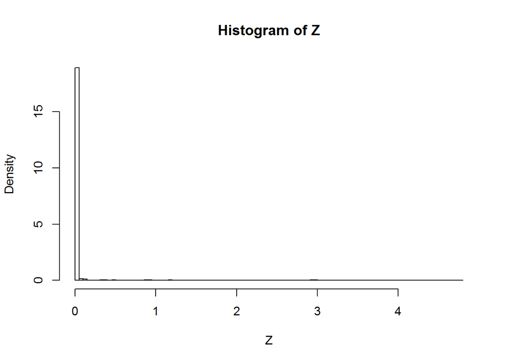

```r
hist (Z, breaks=100, probability = 1)
```

**4. Simulate the distribution density function of fZ(z)=(1/2)e(-lambda X Z) .**

```r
diff = sim.diff.exp()
```

**5. Plot the distribution density function for fZ(z)=(1/2)e(-lambda X Z) .**

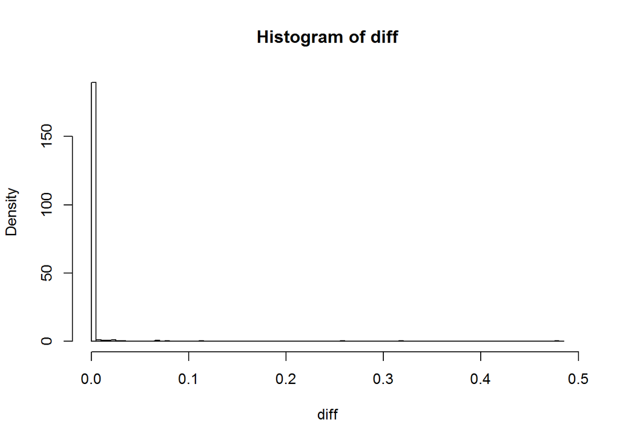

```r
hist(diff,breaks=100, probability = 1)
```

### Chapter 8 Exercise 1

**Let X be a continuous random variable with mean=10 and variance =100/3. Using Chebyshev’s Inequality, find an upper bound for the following probabilities.**

**a. P(abs(X-10)>= 2)** **b. P(abs(X-10)>= 5)** **c. P(abs(X-10)>= 9)** **d. P(abs(X-10)>= 20)**

```r
cheb.prob = function(mean = 10, var=100/3, k)
{
  prob = ifelse((var/k^2) > 1, 1,var/k^2)
  return(prob)
}

print(paste("P(abs(X-10)>= 2) = ",cheb.prob(k=2)))
```

```
## [1] "P(abs(X-10)>= 2) =  1"
```

```r
print(paste("P(abs(X-10)>= 5) = ",cheb.prob(k=5)))
```

```
## [1] "P(abs(X-10)>= 5) =  1"
```

```r
print(paste("P(abs(X-10)>= 9) = ",cheb.prob(k=9)))
```

```
## [1] "P(abs(X-10)>= 9) =  0.411522633744856"
```

```r
print(paste("P(abs(X-10)>= 20) = ",cheb.prob(k=20)))
```

```
## [1] "P(abs(X-10)>= 20) =  0.0833333333333333"
```